# The Correlation Between Taking Cold Showers and Adrenaline Levels.

Jadyn Eleccion

March 15th, 2025

# Term Project Description

My project builds upon the study referenced below. I have proposed a potential follow-up experiment to extend the study’s findings. The project utilizes simulated data, structured and analyzed as if collected from a real experiment. While the outcomes do not provide scientific evidence, they showcase my skills in formulating and addressing relevant biological questions through statistics, experimental design, and programming.

### Article citation:

Buijze, G. A., Sierevelt, I. N., van der Heijden, B. C. J. M., Dijkgraaf, M. G., & Frings-Dresen, M. H. W. (2016). The effect of cold showering on health and work: A randomized controlled trial. PLoS ONE, 11(9), e0161749. https://doi.org/10.1371/journal.pone.0161749

### Brief statement on the findings from the original article that led to your followup experiment:

From the original article, the findings concluded that cold showers did have a statistical improvement in the reduction of self-reported sickness and absences from work. These findings led up to my follow up experiment to see if cold showers had an effect on epinephrine levels

# The Question

Do cold showers affect adrenaline levels?

#### Disclaimer: This project analyzes simulated data. The questions and hypotheses are real, but the results and conclusions are not.

### *Rationale and Background:*

Epinephrine, or adrenaline acts as both a neurotransmitter and a hormone. It resides on top of each kidney shaped like a hats. As a neurotransmitter, it plays a small role in metabolism, attention, focus, excitement, etc. However, epinephrine’s main role is as a hormone. It is released by the adrenal glands that respond to stress. Thus resulting in psychological changes in the body to what is known as the “flight-or-fight” response (Cleveland Clinic 2022). After the brain receives any indication of danger, the neurotransmitter in the brain sends a signal causing a series of changes to happen; your pupils dilate, your heart pumps faster, and muscles receive more blood flow (Cleveland Clinic 2022). Many individuals such as myself have difficulty waking up in the morning and find it difficult to get their day started. So as a result, some turn to take cold showers in the morning to stimulate alertness by raising their epinephrine levels. Cold showers have been illustrated to activate the nervous system, causing a rise in epinephrine levels, that contribute to alertness, heart rate, blood pressure, and respiratory rate. These responses result in improved mental alertness and focus (Texas Health Resources 2023). Cold exposure to the human body triggers a mechanism in the body through the hypothalamus, signaling to release of epinephrine to combat the coldness. This explains how many can feel more awake after taking a cold shower in the morning. If these individuals can feel alert, they will be more inclined to be productive throughout their day.

# Hypotheses

### *Null Hypothesis:*

Cold showers do not play a significant role on adrenaline levels.

### *Alternative Hypothesis:*

Cold showers do play a significant role on adrenaline levels.

# Experimental Design

This experiment is used to see if cold showers will have an effect on an individuals epinephrine levels. It will consist of 30 participants picked at random, not accounting for their lifestyle or job type. The individuals will first measure their epinephrine levels using a urine test as the baseline. All 30 individuals will be in set in the same environment, and take a shower 10 minutes after the first sample of adrenaline levels are measured. The temperature of the shower will be 68 degrees Fahrenheit. Then, five minutes after their shower, they will take another urine test to measure their epinephrine levels. The same individuals will be both the control and experimental group. The positive control will consist of each individual to go about their night, and in the morning of the following day, the urine test will be conducted. The negative control will be that there is no shower, and it will not have any effect on the individuals epinephrine levels at that time. This will be single blind test, and the participants will not know that the experiment is specifically testing the correlation between cold showers and epinephrine levels, whereas the experimenter will know the experiment between the two.

### *Explanatory and Response Variables:*

My explanatory variable is independent and categorical. The x variable, or independent variable is if the individual takes a cold shower, or no shower at all. The response/dependent/y variable is the individual’s epinephrine levels.

### *Alpha:*

The alpha level will be at a 0.05 level of significance.

### *Sample size:*

The sample size for this study is 30 people.

### *Sample size justification:*

I believe this is an appropriate amount because it is an adequate amount of people to test for a significant difference, while remaining manageable in terms of finding willing participants to join the study. With a sample size of 30, assumptions of normality allow an account for a valid analysis. Although the sample size is pretty small, it is easier to account for an contraints while also producing results that can be deemed significant. The effect sized is estimated to be 0.5 which was estimated by using Cohen’s d test. Thus illustrating a medium effect size, which is a good size to show if there is a statistical significance in adrenaline levels.

# Data Analysis Plan

Paired t-test

# Assumptions and Exploratory Data Analysis (EDA)

```r
library(tidyverse)
ShowerData<- read.csv("jeleccion.csv")
TidyShower <- pivot_longer(ShowerData, cols =2:3, names_to = "ExperimentalGroup", values_to = "ControlGroup")
head(TidyShower)
```

| X | ExperimentalGroup | ControlGroup |
| --- | --- | --- |
| 1 | ExperimentalGroup | 2.385231 |
| 1 | ControlGroup | 2.026015 |
| 2 | ExperimentalGroup | 3.073515 |
| 2 | ControlGroup | 2.335879 |
| 3 | ExperimentalGroup | 2.063587 |
| 3 | ControlGroup | 1.373407 |

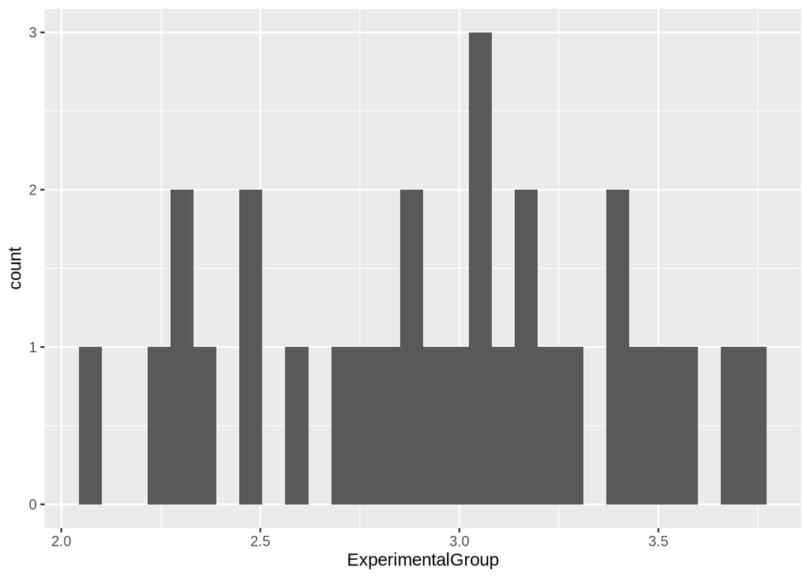

```r
Histogram1 <- ggplot(data=ShowerData,mapping=aes(x=ExperimentalGroup))+geom_histogram()
Histogram1
```

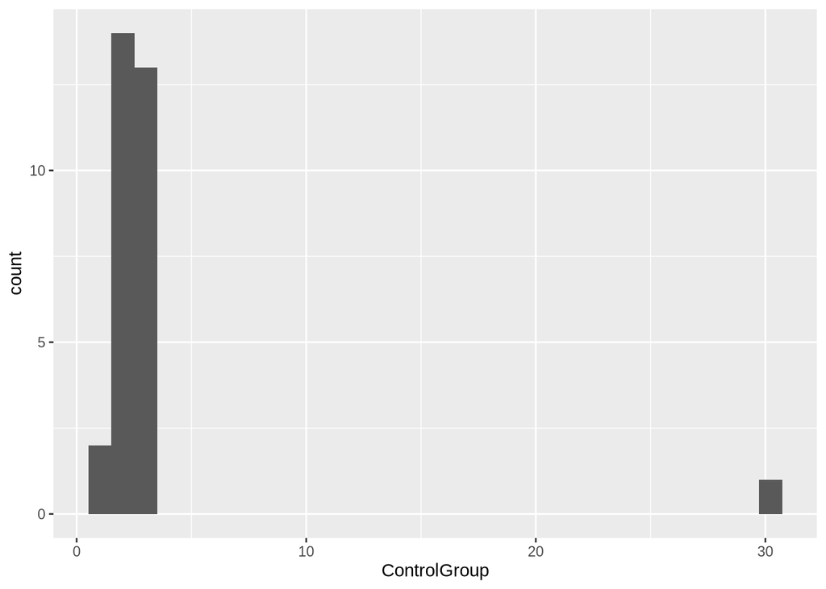

```r
Histogram2 <- ggplot(data=ShowerData,mapping=aes(x=ControlGroup))+geom_histogram()
Histogram2
```

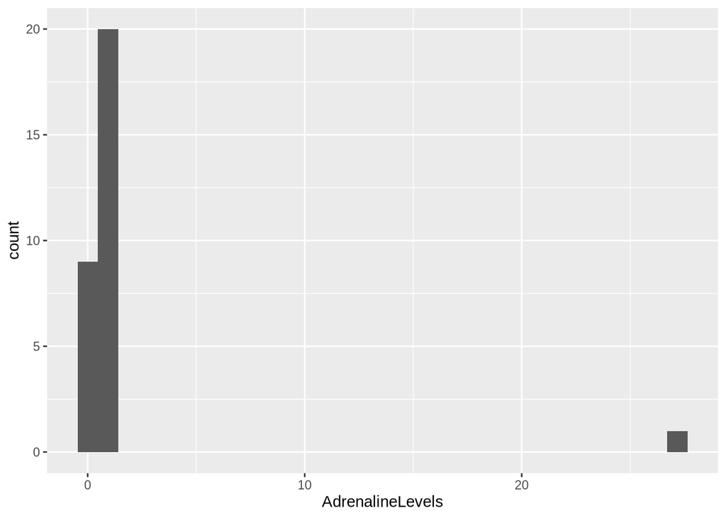

```r
ShowerData$AdrenalineLevels <- abs(ShowerData$ExperimentalGroup - ShowerData$ControlGroup)

Histogram3 <- ggplot(data=ShowerData,mapping=aes(x=AdrenalineLevels))+geom_histogram()
Histogram3
```

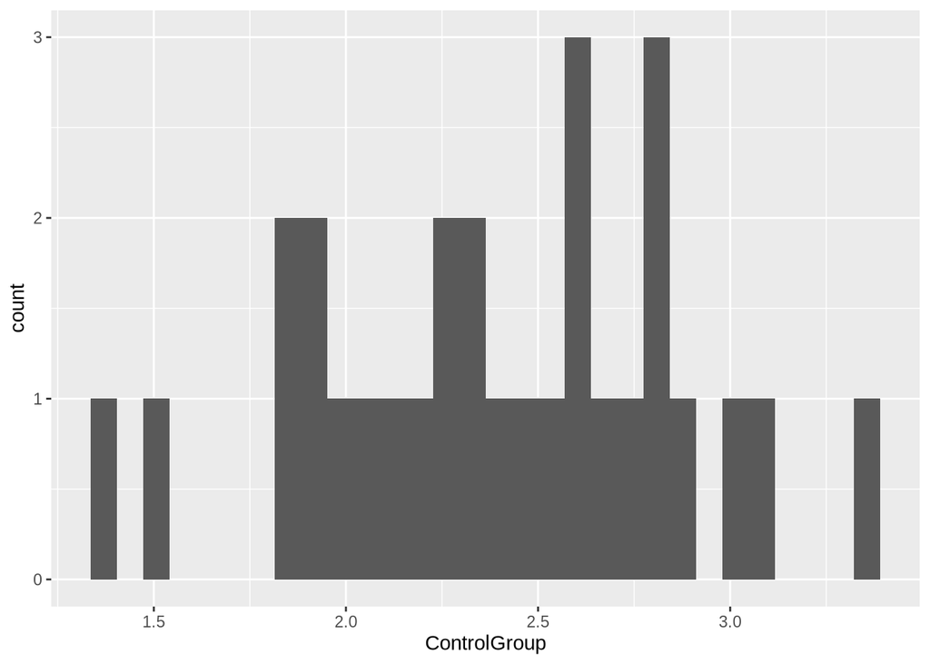

```r
Q1 <- quantile(ShowerData$ControlGroup, 0.25)
Q3 <- quantile(ShowerData$ControlGroup, 0.75)
IQR <- Q3 - Q1
lower_bound <- Q1 - 1.5 * IQR
upper_bound <- Q3 + 1.5 * IQR

ShowerData <- ShowerData %>% filter(ControlGroup >= lower_bound & ControlGroup <= upper_bound)

ShowerData$AdrenalineLevels <- abs(ShowerData$ExperimentalGroup - ShowerData$ControlGroup)

Histogram2_updated <- ggplot(data=ShowerData, mapping=aes(x=ControlGroup)) + geom_histogram()
Histogram2_updated
```

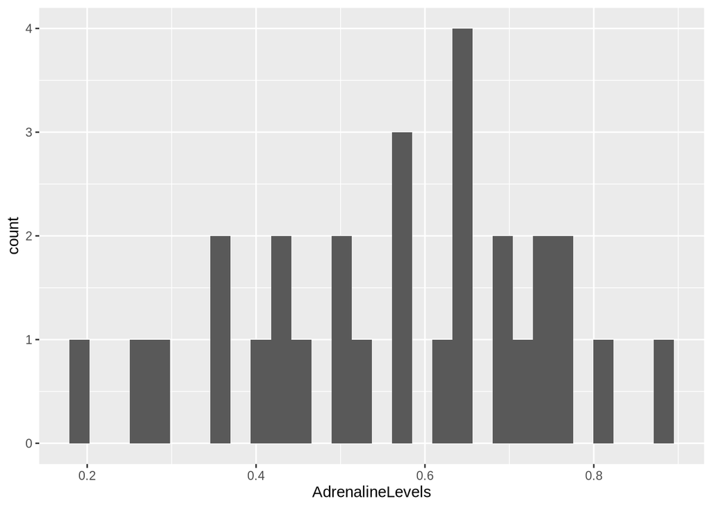

```r
Histogram3_updated <- ggplot(data=ShowerData, mapping=aes(x=AdrenalineLevels)) + geom_histogram()
Histogram3_updated
```